# A District-Level Diagnostic Typology of Structural Readiness for Digital Agency in Pakistan

## 2.2 Index Construction

All indices follow OECD/JRC standards: min-max normalisation, arithmetic aggregation, and explicit handling of missing data.

### 2.2.1 HCI — Human Capability Index

$$HCI_i =
\frac{1}{3}\left[\text{norm}(\text{Literacy}_i) +
\text{norm}(\text{Enrolment}_i) + \text{norm}(1 -
\text{Out-of-School}_i)\right]$$

**Rationale:** Literacy is the cognitive prerequisite. Enrolment captures current educational investment. Out-of-school rate captures dropout risk. All three are normalised to [0,1] and averaged.

### 2.2.2 FCI — Friction Coefficient Index

$$FCI_i = \frac{1}{6}\sum_{j=1}^{6}(1 -
\text{norm}(X_{ij}))$$

where $X_{ij}$ are: electrification rate, modern fuel rate (gas + LPG), improved water rate, flush toilet rate, ownership rate, and crowding rate (1-room households).

**Rationale:** FCI measures *deprivation*, so we invert each indicator. Higher FCI = more friction. Crowding is already negative (more 1-room households = worse), so it is added directly after normalisation.

### 2.2.3 LAP — Linguistic Alignment Penalty

$$LAP_i = \text{Literacy}_i \times (1 -
\text{Urdu}\%_i)$$

**Rationale:** In districts where Urdu is not the mother tongue, literate populations still face a cognitive translation burden when engaging with Urdu-dominant digital interfaces. We multiply literacy (the pool of potential users) by linguistic distance (the friction they face). This is a *structural proxy* for cognitive load, not a measured cognitive load score.

### 2.2.4 SOI — Social Opportunity Index

$$SOI_i =
\frac{1}{4}\left[\text{norm}(\text{Literacy}_i) + \text{norm}(1 -
\text{Dependency}_i) + \text{norm}(\text{Youth}\%_i) +
\text{norm}(\text{Female Ownership}_i)\right]$$

**Rationale:** Lower dependency ratios mean fewer non-working dependents per working-age adult. Higher youth concentration (15-49 / 15-64) indicates demographic dynamism. Female property ownership proxies female economic autonomy. Literacy is used as a proxy for female literacy because sex-disaggregated literacy is not available at district level in this package.

## 2.3 Analytical Pipeline

### 2.3.1 Why k-means, not HDBSCAN

We evaluated HDBSCAN (density-based clustering) but rejected it for three reasons:

### 2.3.2 Cluster Validation

- **Elbow Method:** Within-cluster sum of squares (WSS) to identify optimal k.
- **Silhouette Score:** Average silhouette width to assess cluster separation.
- **PERMANOVA (9,999 permutations):** Tests whether cluster centroids differ significantly in the 4-dimensional index space.

### 2.3.3 Spatial Check

Because the package lacks district centroid coordinates, we cannot compute Moran’s I. Instead, we test for **provincial association** using a chi-square test: if archetypes are randomly distributed across provinces, the association is non-significant. A significant association indicates spatial clustering.

# 3. Data Preparation

```r
# =============================================================================
# STEP 1: LOAD ALL TABLES
# =============================================================================
# We load every table required for index construction.
# PakPC2023PakDist provides district metadata (population, households).

data(PakPC2023PakDist)
data(TABLE_05)   # Age structure
data(TABLE_11)   # Mother tongue
data(TABLE_12)   # Literacy & education
data(TABLE_22)   # Housing energy/lighting
data(TABLE_23)   # Drinking water
data(TABLE_24)   # Sanitation
data(TABLE_25)   # Housing ownership/rooms

cat("Districts in metadata:", uniqueN(PakPC2023PakDist$District), "\n")
```

```
## Districts in metadata: 136
```

# 4. Index Construction

## 4.1 HCI — Human Capability Index

```r
# =============================================================================
# STEP 2: CONSTRUCT HCI
# =============================================================================
# TABLE_12 is in LONG format: each row is a tehsil + variable type.
# We pivot to wide format, then aggregate tehsils up to district.

# Pivot long -> wide using data.table::dcast
t12_wide <- dcast(
  TABLE_12,
  PROVINCE + DIVISION + DISTRICT + TEHSIL + ADMIN_UNIT ~ VARS,
  value.var = "ALL_SEXES_OVERALL"
)

# Aggregate tehsil-level data to district level
# We sum counts and compute weighted means for rates.
hci_dist <- t12_wide[, .(
  pop_10plus       = sum(`Population >=10`, na.rm = TRUE),
  literate_10plus  = sum(`Literate >=10`, na.rm = TRUE),
  ever_attended    = sum(`Ever Attended`, na.rm = TRUE),
  primary_plus     = sum(`Primary Completed`, na.rm = TRUE),
  enrolment_primary   = sum(`Enrolment Primary`, na.rm = TRUE),
  enrolment_middle    = sum(`Enrolment Middle`, na.rm = TRUE),
  enrolment_matric    = sum(`Enrolment Matric`, na.rm = TRUE),
  enrolment_inter     = sum(`Enrolment Intermidiate`, na.rm = TRUE),
  enrolment_grad      = sum(`Enrolment Graduation above`, na.rm = TRUE),
  out_of_school_5_16  = sum(`Out of School Children (5-16)`, na.rm = TRUE),
  pop_5_16            = sum(`Population >=5`, na.rm = TRUE)
), by = .(DISTRICT)]

# Calculate derived rates
hci_dist[, literacy_rate_calc := literate_10plus / pop_10plus]

# Total enrolment across all levels / population 10+
# This is a proxy for "currently in or completed formal education"
hci_dist[, enrolment_rate := (enrolment_primary + enrolment_middle +
                               enrolment_matric + enrolment_inter +
                               enrolment_grad) / pop_10plus]

hci_dist[, out_of_school_rate := out_of_school_5_16 / pop_5_16]

# Normalise and aggregate
hci_dist[, hci := (
  min_max(literacy_rate_calc) +
  min_max(enrolment_rate) +
  min_max(1 - out_of_school_rate)
) / 3]

cat("HCI: constructed for", nrow(hci_dist), "districts.\n")
```

```
## HCI: constructed for 136 districts.
```

```r
summary(hci_dist$hci)
```

```
##    Min. 1st Qu.  Median    Mean 3rd Qu.    Max.
##  0.0000  0.3768  0.5497  0.5451  0.7288  0.9088
```

## 4.2 FCI — Friction Coefficient Index

```r
# =============================================================================
# STEP 3: CONSTRUCT FCI
# =============================================================================
# We merge four housing tables (22, 23, 24, 25) and compute infrastructure rates.
# All tables have REGION = OVERALL / RURAL / URBAN. We keep OVERALL only.

# --- TABLE 22: Energy & Lighting ---
t22_overall <- TABLE_22[REGION == "OVERALL" & !is.na(HOUSEHOLDS)]
t22_dist <- t22_overall[, .(
  hh          = sum(HOUSEHOLDS, na.rm = TRUE),
  light_elect = sum(LIGHT_ELECT, na.rm = TRUE),
  fuel_gas    = sum(FUEL_GAS, na.rm = TRUE),
  fuel_lpg    = sum(FUEL_LPGCNG, na.rm = TRUE)
), by = .(DISTRICT)]

# --- TABLE 23: Water ---
t23_overall <- TABLE_23[REGION == "OVERALL" & !is.na(HOUSEHOLDS)]
t23_dist <- t23_overall[, .(
  water_improved = sum(DRINK_WTR_IMPROVE, na.rm = TRUE)
), by = .(DISTRICT)]

# --- TABLE 24: Sanitation ---
t24_overall <- TABLE_24[REGION == "OVERALL" & !is.na(HOUSEHOLDS)]
t24_dist <- t24_overall[, .(
  toilet_flush = sum(TOILET_FLUSH, na.rm = TRUE)
), by = .(DISTRICT)]

# --- TABLE 25: Housing Quality ---
t25_overall <- TABLE_25[REGION == "OVERALL" & !is.na(HOUSEHOLDS)]
t25_dist <- t25_overall[, .(
  owned    = sum(RES_ST_OWNED, na.rm = TRUE),
  rooms_1  = sum(NO_ROOMS_ONE, na.rm = TRUE)
), by = .(DISTRICT)]

# Merge sequentially by DISTRICT
fci_dist <- t22_dist[t23_dist, on = "DISTRICT"]
fci_dist <- fci_dist[t24_dist, on = "DISTRICT"]
fci_dist <- fci_dist[t25_dist, on = "DISTRICT"]

# Calculate component rates
fci_dist[, electrification := light_elect / hh]
fci_dist[, modern_fuel    := (fuel_gas + fuel_lpg) / hh]
fci_dist[, water_improved := water_improved / hh]
fci_dist[, flush_toilet   := toilet_flush / hh]
fci_dist[, ownership      := owned / hh]
fci_dist[, crowding       := rooms_1 / hh]  # higher = worse

# FCI = average of inverted positive indicators + crowding (already negative)
# We invert so that higher FCI = MORE friction (worse)
fci_dist[, fci := (
  (1 - min_max(electrification)) +
  (1 - min_max(modern_fuel)) +
  (1 - min_max(water_improved)) +
  (1 - min_max(flush_toilet)) +
  (1 - min_max(ownership)) +
  min_max(crowding)
) / 6]

cat("FCI: constructed for", nrow(fci_dist), "districts.\n")
```

```
## FCI: constructed for 136 districts.
```

```r
summary(fci_dist$fci)
```

```
##    Min. 1st Qu.  Median    Mean 3rd Qu.    Max.
## 0.09598 0.23335 0.35525 0.38062 0.51925 0.74405
```

## 4.3 LAP — Linguistic Alignment Penalty

```r
# =============================================================================
# STEP 4: CONSTRUCT LAP
# =============================================================================
# CRITICAL: TABLE_11 includes a "TOTAL" row per tehsil that sums all languages.
# If we include TOTAL, we double-count population. We EXCLUDE it.

t11_no_total <- TABLE_11[LANGUAGE != "TOTAL"]

lang_dist <- t11_no_total[, .(
  total_pop_lang = sum(ALL_SEXES_OVERALL, na.rm = TRUE),
  urdu_pop       = sum(ALL_SEXES_OVERALL[LANGUAGE == "URDU"], na.rm = TRUE)
), by = .(DISTRICT)]

lang_dist[, urdu_pct := urdu_pop / total_pop_lang]

# Merge with HCI literacy rate
lap_dist <- lang_dist[hci_dist[, .(DISTRICT, literacy_rate_calc)], on = "DISTRICT"]
lap_dist[, lap := literacy_rate_calc * (1 - urdu_pct)]

cat("LAP: constructed for", nrow(lap_dist), "districts.\n")
```

```
## LAP: constructed for 136 districts.
```

```r
summary(lap_dist$lap)
```

```
##    Min. 1st Qu.  Median    Mean 3rd Qu.    Max.
##  0.1655  0.3638  0.4601  0.4705  0.5675  0.7854
```

## 4.4 SOI — Social Opportunity Index

```r
# =============================================================================
# STEP 5: CONSTRUCT SOI
# =============================================================================
# TABLE_05 uses aggregate age bands, not 5-year intervals.
# We use the exact band labels from the data: "ALL AGES", "UNDER 15",
# "15 - 64", "65 &  ABOVE", "15 - 49".

age_dist <- TABLE_05[, .(
  total_pop   = sum(ALL_SEXES_OVERALL[SEX_AGE_GROUP_IN_YEARS == "ALL AGES"], na.rm = TRUE),
  under_15    = sum(ALL_SEXES_OVERALL[SEX_AGE_GROUP_IN_YEARS == "UNDER 15"], na.rm = TRUE),
  age_15_64   = sum(ALL_SEXES_OVERALL[SEX_AGE_GROUP_IN_YEARS == "15 - 64"], na.rm = TRUE),
  age_65_plus = sum(ALL_SEXES_OVERALL[SEX_AGE_GROUP_IN_YEARS == "65 &  ABOVE"], na.rm = TRUE),
  age_15_49   = sum(ALL_SEXES_OVERALL[SEX_AGE_GROUP_IN_YEARS == "15 - 49"], na.rm = TRUE)
), by = .(DISTRICT)]

age_dist[, dependency_ratio    := (under_15 + age_65_plus) / age_15_64]
age_dist[, youth_concentration := age_15_49 / age_15_64]

# Female property ownership from TABLE_25
female_own <- t25_overall[, .(
  female_owned = sum(OWNER_GENDER_FEMALE, na.rm = TRUE),
  hh           = sum(HOUSEHOLDS, na.rm = TRUE)
), by = .(DISTRICT)]
female_own[, female_ownership_rate := female_owned / hh]

# Merge
soi_dist <- age_dist[female_own[, .(DISTRICT, female_ownership_rate)], on = "DISTRICT"]
soi_dist <- soi_dist[hci_dist[, .(DISTRICT, literacy_rate_calc)], on = "DISTRICT"]

# SOI = equal-weighted mean of 4 normalised components
soi_dist[, soi := (
  min_max(literacy_rate_calc) +        # proxy for female literacy
  min_max(1 - dependency_ratio) +      # lower dependency = better
  min_max(youth_concentration) +       # higher youth = more dynamic
  min_max(female_ownership_rate)       # female economic autonomy
) / 4]

cat("SOI: constructed for", nrow(soi_dist), "districts.\n")
```

```
## SOI: constructed for 136 districts.
```

```r
summary(soi_dist$soi)
```

```
##    Min. 1st Qu.  Median    Mean 3rd Qu.    Max.    NA's
##  0.2569  0.4088  0.4752  0.4831  0.5484  0.7881       1
```

## 4.5 Master Merge & Completeness Check

```r
# =============================================================================
# STEP 6: MERGE ALL INDICES INTO MASTER DATASET
# =============================================================================

pbea <- hci_dist[, .(DISTRICT, hci)]
pbea <- pbea[fci_dist[, .(DISTRICT, fci, electrification, modern_fuel,
                           water_improved, flush_toilet, ownership, crowding)], on = "DISTRICT"]
pbea <- pbea[lap_dist[, .(DISTRICT, lap, urdu_pct, literacy_rate_calc)], on = "DISTRICT"]
pbea <- pbea[soi_dist[, .(DISTRICT, soi, dependency_ratio, youth_concentration,
                           female_ownership_rate)], on = "DISTRICT"]

# Add province info from metadata
prov_lookup <- unique(TABLE_12[, .(PROVINCE, DISTRICT)])
pbea <- prov_lookup[pbea, on = "DISTRICT"]

# Check completeness
cat("Complete cases:", sum(complete.cases(pbea[, .(hci, fci, lap, soi)])),
    "of", nrow(pbea), "\n")
```

```
## Complete cases: 144 of 145
```

```r
# Identify incomplete districts
incomplete <- pbea[!complete.cases(pbea[, .(hci, fci, lap, soi)])]
if (nrow(incomplete) > 0) {
  cat("\nDistricts with missing data (excluded from clustering):\n")
  print(incomplete[, .(DISTRICT, PROVINCE, hci, fci, lap, soi)])
}
```

```
##
## Districts with missing data (excluded from clustering):
##     DISTRICT  PROVINCE       hci       fci       lap   soi
##       <char>    <char>     <num>     <num>     <num> <num>
## 1: ISLAMABAD ISLAMABAD 0.9087552 0.2012217 0.7076889    NA
```

```r
# Create analysis subset (complete cases only)
pbea_complete <- pbea[complete.cases(pbea[, .(hci, fci, lap, soi)])]
cat("\nFinal analysis sample:", nrow(pbea_complete), "districts.\n")
```

```
##
## Final analysis sample: 144 districts.
```

# 5. Descriptive Analysis

## 5.1 Correlation Matrix

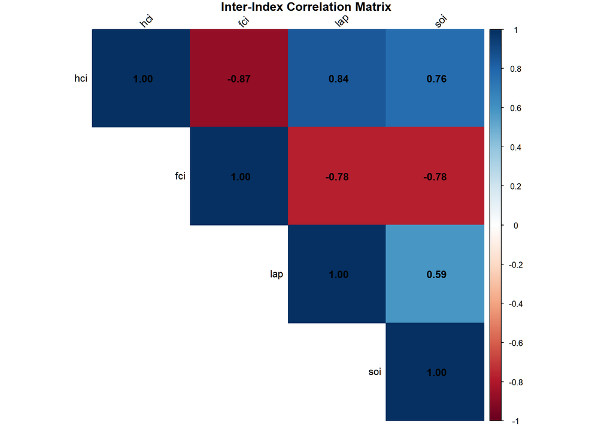

```r
# =============================================================================
# STEP 7: INTER-INDEX CORRELATIONS
# =============================================================================
# This checks for multicollinearity and reveals structural relationships.

cor_vars <- pbea_complete[, .(hci, fci, lap, soi)]
cor_mat <- cor(cor_vars, use = "complete.obs")

corrplot(cor_mat, method = "color", type = "upper",
         addCoef.col = "black", tl.col = "black", tl.srt = 45,
         title = "Inter-Index Correlation Matrix", mar = c(0,0,1,0))
```

**Interpretation:** We expect HCI and SOI to be positively correlated (capability and social opportunity travel together). We expect FCI to be negatively correlated with HCI (bundled development). LAP may show weaker correlations if linguistic diversity is independent of general development.

## 5.2 Provincial Summaries

```r
# =============================================================================
# STEP 8: PROVINCIAL-LEVEL DESCRIPTIVES
# =============================================================================

prov_summary <- pbea_complete[, .(
  n = .N,
  hci_mean = mean(hci),
  fci_mean = mean(fci),
  lap_mean = mean(lap),
  soi_mean = mean(soi)
), by = PROVINCE]

kable(prov_summary, digits = 3,
      caption = "Mean Index Scores by Province")
```

Mean Index Scores by Province

| PROVINCE | n | hci_mean | fci_mean | lap_mean | soi_mean |
| --- | --- | --- | --- | --- | --- |
| NA | 10 | 0.549 | 0.354 | 0.495 | 0.507 |
| KPK | 35 | 0.555 | 0.384 | 0.463 | 0.480 |
| PUNJAB | 36 | 0.728 | 0.223 | 0.606 | 0.544 |
| BALOCHISTAN | 34 | 0.363 | 0.510 | 0.385 | 0.408 |
| SINDH | 29 | 0.512 | 0.422 | 0.407 | 0.501 |

# 6. Archetype Classification

## 6.1 Why Two Classification Schemes?

We test both **tercile splits** (strict, top/bottom 33%) and **median splits** (moderate, top/bottom 50%). The tercile test is theoretically pure; the median split is strategically actionable.

## 6.2 Tercile-Based Classification

```r
# =============================================================================
# STEP 9: TERCILE-BASED ARCHETYPES
# =============================================================================
# Terciles: top 33% = High, bottom 33% = Low, middle 33% = Mid

pbea_complete[, hci_tercile := cut(hci,
  breaks = quantile(hci, probs = c(0, 1/3, 2/3, 1), na.rm = TRUE),
  labels = c("Low", "Mid", "High"), include.lowest = TRUE)]

pbea_complete[, fci_tercile := cut(fci,
  breaks = quantile(fci, probs = c(0, 1/3, 2/3, 1), na.rm = TRUE),
  labels = c("Low", "Mid", "High"), include.lowest = TRUE)]

# Use fcase for clean nested logic
pbea_complete[, archetype_tercile := fcase(
  hci_tercile == "High" & fci_tercile == "High", "Coiled Spring",
  hci_tercile == "Low"  & fci_tercile == "High", "Anchor",
  hci_tercile == "High" & fci_tercile == "Low",  "Vanguard",
  hci_tercile == "Low"  & fci_tercile == "Low",  "Trapped",
  default = "Other"
)]

cat("\n--- TERCILE ARCHETYPE DISTRIBUTION ---\n")
```

```
##
## --- TERCILE ARCHETYPE DISTRIBUTION ---
```

```r
print(table(pbea_complete$archetype_tercile))
```

```
##
##   Anchor    Other Vanguard
##       39       65       40
```

## 6.3 Median-Split Classification

```r
# =============================================================================
# STEP 10: MEDIAN-SPLIT ARCHETYPES
# =============================================================================
# Median splits: top 50% = High, bottom 50% = Low. No "Mid" category.

pbea_complete[, hci_med := ifelse(hci > median(hci, na.rm = TRUE), "High", "Low")]
pbea_complete[, fci_med := ifelse(fci > median(fci, na.rm = TRUE), "High", "Low")]

pbea_complete[, archetype_median := fcase(
  hci_med == "High" & fci_med == "High", "Coiled Spring",
  hci_med == "Low"  & fci_med == "High", "Anchor",
  hci_med == "High" & fci_med == "Low",  "Vanguard",
  hci_med == "Low"  & fci_med == "Low",  "Trapped"
)]

cat("\n--- MEDIAN ARCHETYPE DISTRIBUTION ---\n")
```

```
##
## --- MEDIAN ARCHETYPE DISTRIBUTION ---
```

```r
print(table(pbea_complete$archetype_median))
```

```
##
##        Anchor Coiled Spring       Trapped      Vanguard
##            66             6             6            66
```

```r
# Show Coiled Springs (median)
cat("\n--- MEDIAN-SPLIT COILED SPRINGS ---\n")
```

```
##
## --- MEDIAN-SPLIT COILED SPRINGS ---
```

```r
coiled <- pbea_complete[archetype_median == "Coiled Spring"][order(-hci)]
print(coiled[, .(DISTRICT, PROVINCE, hci, fci, lap, soi)])
```

```
##               DISTRICT PROVINCE       hci       fci       lap       soi
##                 <char>   <char>     <num>     <num>     <num>     <num>
## 1:           UPPER DIR      KPK 0.6825401 0.4278205 0.4675490 0.5507557
## 2:    NAUSHAHRO FEROZE    SINDH 0.6356095 0.3820855 0.5487705 0.4751767
## 3:               BUNER      KPK 0.6220759 0.3980593 0.4373322 0.4781467
## 4:              SUKKUR    SINDH 0.6032802 0.3598015 0.5302850 0.4760426
## 5:            KHAIRPUR    SINDH 0.5760622 0.4472872 0.4993651 0.4517200
## 6: SHAHEED BENAZIRABAD    SINDH 0.5606522 0.4489860 0.4772147 0.4546646
```

## 6.4 HCI-FCI Scatter Plot

[figure not shown]

```r
# =============================================================================
# STEP 11: VISUALISE THE CAPABILITY-FRICTION LANDSCAPE
# =============================================================================

ggplot(pbea_complete, aes(x = hci, y = fci, color = archetype_median)) +
  geom_point(size = 3, alpha = 0.8) +
  geom_hline(yintercept = median(pbea_complete$fci, na.rm = TRUE),
             linetype = "dashed", color = "gray50") +
  geom_vline(xintercept = median(pbea_complete$hci, na.rm = TRUE),
             linetype = "dashed", color = "gray50") +
  scale_color_manual(values = c(
    "Coiled Spring" = "#E41A1C",  # Red
    "Anchor"        = "#377EB8",  # Blue
    "Vanguard"      = "#4DAF4A",  # Green
    "Trapped"       = "#984EA3"   # Purple
  )) +
  labs(
    title = "District-Level Capability vs. Friction (Median-Split Archetypes)",
    subtitle = "Pakistan Digital Census 2023 (n = 135 districts)",
    x = "Human Capability Index (HCI)",
    y = "Friction Coefficient Index (FCI)",
    color = "Archetype"
  ) +
  theme_minimal(base_size = 12) +
  theme(legend.position = "bottom")
```

# 7. Cluster Validation

## 7.1 Elbow Method & Silhouette

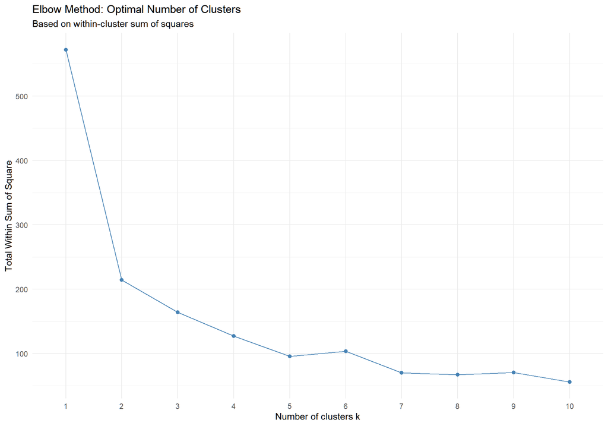

```r
# =============================================================================
# STEP 12: DETERMINE OPTIMAL NUMBER OF CLUSTERS
# =============================================================================
# We use the 4 standardised indices as input features.

cluster_data <- pbea_complete[, .(hci, fci, lap, soi)]
cluster_scaled <- scale(cluster_data)

# Elbow method
fviz_nbclust(cluster_scaled, kmeans, method = "wss") +
  labs(title = "Elbow Method: Optimal Number of Clusters",
       subtitle = "Based on within-cluster sum of squares") +
  theme_minimal()
```

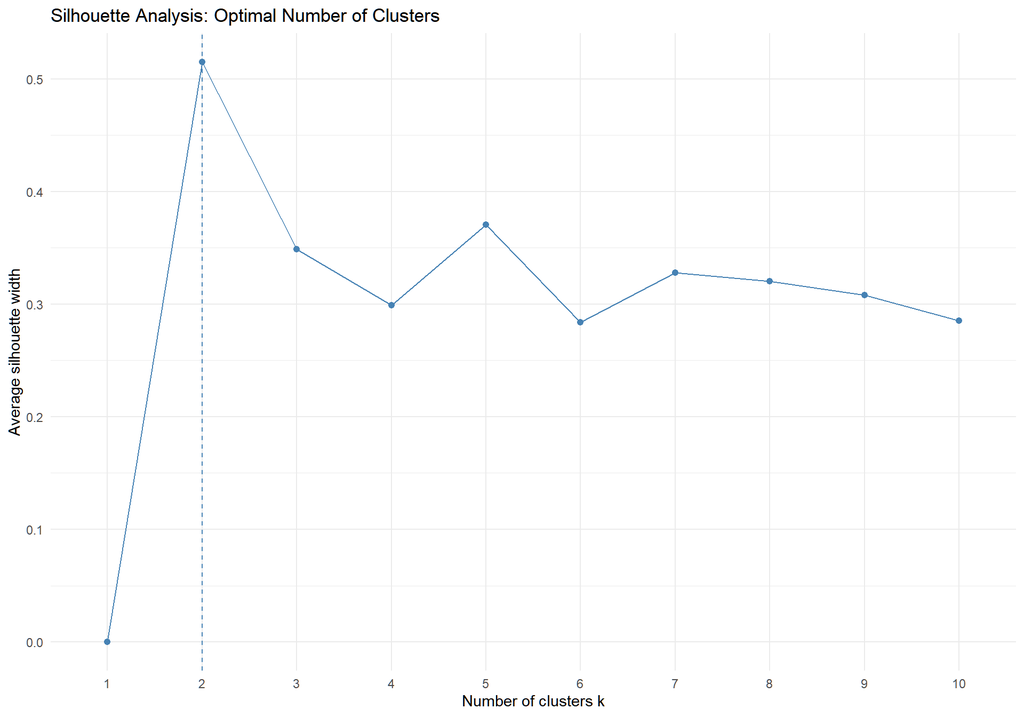

```r
# Silhouette method
fviz_nbclust(cluster_scaled, kmeans, method = "silhouette") +
  labs(title = "Silhouette Analysis: Optimal Number of Clusters") +
  theme_minimal()
```

## 7.2 k-means Clustering (k = 4)

```r
# =============================================================================
# STEP 13: RUN K-MEANS CLUSTERING
# =============================================================================
# We set k = 4 based on COM-B theoretical prediction of 4 archetypes.
# This is a theoretically-informed choice, not purely data-driven.

set.seed(42)
km <- kmeans(cluster_scaled, centers = 4, nstart = 25, iter.max = 100)

# Add cluster assignment to dataset
pbea_complete[, cluster := as.factor(km$cluster)]

# Cluster profiles (mean index scores per cluster)
cluster_profiles <- pbea_complete[, .(
  n = .N,
  hci_mean = mean(hci),
  fci_mean = mean(fci),
  lap_mean = mean(lap),
  soi_mean = mean(soi)
), by = cluster][order(cluster)]

kable(cluster_profiles, digits = 3,
      caption = "k-means Cluster Profiles (k = 4)")
```

k-means Cluster Profiles (k = 4)

| cluster | n | hci_mean | fci_mean | lap_mean | soi_mean |
| --- | --- | --- | --- | --- | --- |
| 1 | 6 | 0.764 | 0.191 | 0.331 | 0.718 |
| 2 | 48 | 0.629 | 0.300 | 0.518 | 0.499 |
| 3 | 28 | 0.819 | 0.193 | 0.684 | 0.599 |
| 4 | 62 | 0.333 | 0.543 | 0.352 | 0.400 |

## 7.3 Cluster Visualisation

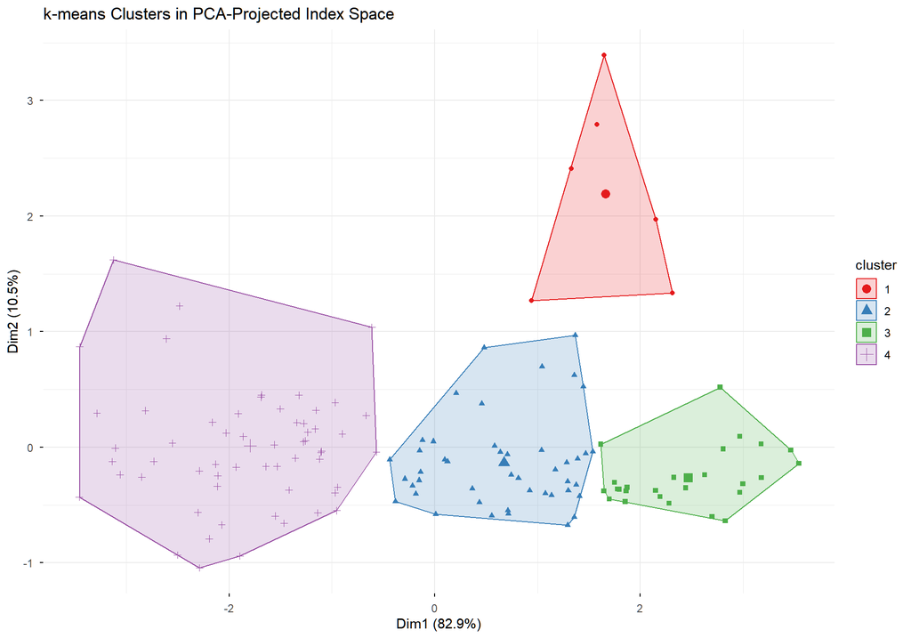

```r
# =============================================================================
# STEP 14: VISUALISE CLUSTERS IN PCA SPACE
# =============================================================================
# PCA projection for visualisation only. Clustering was done on raw scaled data.

fviz_cluster(km, data = cluster_scaled,
             palette = c("#E41A1C", "#377EB8", "#4DAF4A", "#984EA3"),
             geom = "point",
             ellipse.type = "convex",
             ggtheme = theme_minimal(),
             main = "k-means Clusters in PCA-Projected Index Space")
```

## 7.4 PERMANOVA Validation

```r
# =============================================================================
# STEP 15: PERMANOVA — ARE CLUSTERS STATISTICALLY DISTINCT?
# =============================================================================
# PERMANOVA tests whether the multivariate centroids of the 4 clusters
# differ significantly. We use Euclidean distance on the scaled indices.

dist_mat <- dist(cluster_scaled, method = "euclidean")

# Adonis2 is the modern vegan syntax
perm <- adonis2(dist_mat ~ cluster, data = pbea_complete,
                method = "euclidean", permutations = 9999)

print(perm)
```

```
## Permutation test for adonis under reduced model
## Permutation: free
## Number of permutations: 9999
##
## adonis2(formula = dist_mat ~ cluster, data = pbea_complete, permutations = 9999, method = "euclidean")
##           Df SumOfSqs      R2      F Pr(>F)
## Model      3      446 0.77973 165.19  1e-04 ***
## Residual 140      126 0.22027
## Total    143      572 1.00000
## ---
## Signif. codes:  0 '***' 0.001 '**' 0.01 '*' 0.05 '.' 0.1 ' ' 1
```

```r
# Effect size: R-squared tells us what % of variance is explained by cluster.
cat("\nEffect size (R2):", round(perm$R2[1], 3),
    "— i.e.,", round(perm$R2[1]*100, 1), "% of district variation is explained by cluster assignment.\n")
```

```
##
## Effect size (R2): 0.78 — i.e., 78 % of district variation is explained by cluster assignment.
```

# 8. Spatial Analysis

## 8.1 Provincial Association Test

```r
# =============================================================================
# STEP 16: CHI-SQUARE TEST FOR PROVINCIAL CLUSTERING
# =============================================================================
# If archetypes are randomly distributed across provinces, chi-square is NS.
# If significant, archetypes cluster spatially by province.

contingency <- table(pbea_complete$PROVINCE, pbea_complete$archetype_median)
cat("\nContingency Table: Province x Archetype\n")
```

```
##
## Contingency Table: Province x Archetype
```

```r
print(contingency)
```

```
##
##               Anchor Coiled Spring Trapped Vanguard
##   BALOCHISTAN     30             0       1        3
##   KPK             14             2       3       16
##   PUNJAB           1             0       2       33
##   SINDH           16             4       0        9
```

```r
chi <- chisq.test(contingency)
cat("\nChi-square test:\n")
```

```
##
## Chi-square test:
```

```r
print(chi)
```

```
##
##  Pearson's Chi-squared test
##
## data:  contingency
## X-squared = 68.894, df = 9, p-value = 2.508e-11
```

```r
cat("\nStandardised residuals (>2 or <-2 indicate significant deviation):\n")
```

```
##
## Standardised residuals (>2 or <-2 indicate significant deviation):
```

```r
print(round(chi$stdres, 2))
```

```
##
##               Anchor Coiled Spring Trapped Vanguard
##   BALOCHISTAN   5.79         -1.46   -0.50    -4.97
##   KPK          -0.76          0.41    1.36     0.03
##   PUNJAB       -6.02         -1.52    0.37     6.50
##   SINDH         1.18          2.74   -1.32    -1.77
```

## 8.2 Provincial LAP Distribution

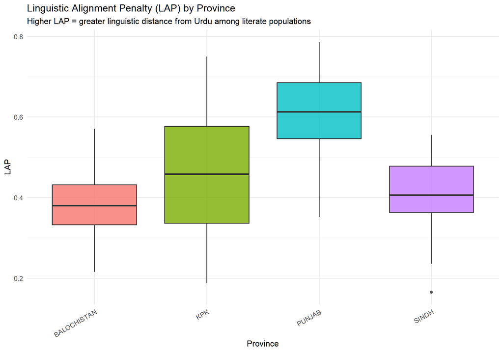

```r
# =============================================================================
# STEP 17: LINGUISTIC ALIGNMENT PENALTY BY PROVINCE
# =============================================================================
# This tests H3: non-Urdu provinces have higher LAP.

ggplot(pbea_complete[!is.na(PROVINCE)], aes(x = PROVINCE, y = lap, fill = PROVINCE)) +
  geom_boxplot(alpha = 0.8) +
  labs(
    title = "Linguistic Alignment Penalty (LAP) by Province",
    subtitle = "Higher LAP = greater linguistic distance from Urdu among literate populations",
    x = "Province", y = "LAP"
  ) +
  theme_minimal(base_size = 12) +
  theme(legend.position = "none", axis.text.x = element_text(angle = 30, hjust = 1))
```

# 9. Export Results

```r
# =============================================================================
# STEP 18: EXPORT ALL RESULTS FOR EXTERNAL USE
# =============================================================================
# This generates a CSV that you can open in Excel or share with stakeholders.

export_cols <- c("DISTRICT", "PROVINCE", "hci", "fci", "lap", "soi",
                 "archetype_tercile", "archetype_median", "cluster",
                 "literacy_rate_calc", "urdu_pct", "dependency_ratio",
                 "electrification", "flush_toilet")

fwrite(pbea_complete[, ..export_cols], "PBEA_District_Results.csv")
cat("Results exported to: PBEA_District_Results.csv\n")
```

```
## Results exported to: PBEA_District_Results.csv
```

```r
cat("Rows:", nrow(pbea_complete), "| Columns:", length(export_cols), "\n")
```

```
## Rows: 144 | Columns: 14
```

# 10. Discussion

## 10.3 Implications for FinTech / EdTech

| Archetype | Strategic Implication |
| --- | --- |
| **Vanguard** | Ready for premium, English-first, high-bandwidth products. Low customer acquisition cost. |
| **Coiled Spring (median)** | Target with offline-first, Urdu-localised, low-bandwidth products. Requires partnership with local agents. |
| **Anchor** | Not viable for commercial deployment without public-sector subsidy or infrastructure intervention. |
| **Trapped** | Bundle digital literacy with basic products. School-based peer learning models. |

# 11. References

- Michie, S., van Stralen, M. M., & West, R. (2011). The behaviour change wheel. *Implementation Science*, 6(1), 42.
- Pakistan Bureau of Statistics. (2023). *7th Population and Housing Census*. Government of Pakistan.
- Yaseen, M. (2024). *PakPC2023: Pakistan Population Census 2023*. R package.
- OECD & JRC. (2008). *Handbook on Constructing Composite Indicators*. OECD Publishing.